# BIOS512 Final Project

## Manual probabilities of getting Lung Cancer

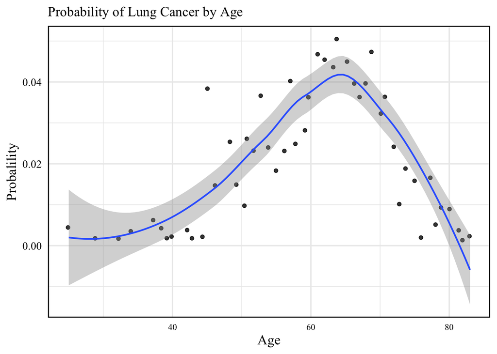

```r
df_lung <- df %>% select(Age, Cancer_Type) %>%
  filter(Cancer_Type == "Lung")

# group_by groups the data
# arrange arranges data

df_lung <- df_lung %>%
  group_by(Age) %>%
  summarise(Counts = length(Cancer_Type)) %>%
  mutate(Probability = Counts/sum(Counts))


  df_lung %>% ggplot(aes(x=Age, y=Probability)) +
  geom_jitter(alpha = 0.8) +
  geom_smooth(linewidth = 0.8) +
  labs(x="Age") +
  labs(y="Probalility") +
  ggtitle("Probability of Lung Cancer by Age") +
  theme_minimal(base_size = 14, base_family = "Times New Roman") +
                                    theme(legend.position = "right",
                                          legend.text = element_text(color = "black", size=11),
                                          legend.title = element_text(color = "black", size=14),
                                          axis.title = element_text(color = "black"),
                                          axis.text.x = element_text(color = "black",size= 9 ),
                                          axis.text.y = element_text(color = "black"),
                                          plot.title = element_text(color = "black", size = 14),
                                          panel.border = element_rect(color = "black", fill = NA, linewidth = 1 ))
```

## Logistic Model using Covariates

```r
df_binary <- df %>%
  mutate(Cancer_Type =
           ifelse(Cancer_Type == "Lung", 1, 0)) %>%
  select(where(is.numeric))

logistic_model <- glm(Cancer_Type ~ Age + Smoking + Alcohol_Use + Obesity + Family_History + Diet_Red_Meat + Diet_Salted_Processed + Fruit_Veg_Intake + Physical_Activity + Air_Pollution + Occupational_Hazards + BRCA_Mutation + H_Pylori_Infection + Calcium_Intake + Physical_Activity_Level,
               family = binomial(link = 'logit'),
               data = df_binary)

summary(logistic_model)
```

```
##
## Call:
## glm(formula = Cancer_Type ~ Age + Smoking + Alcohol_Use + Obesity +
##     Family_History + Diet_Red_Meat + Diet_Salted_Processed +
##     Fruit_Veg_Intake + Physical_Activity + Air_Pollution + Occupational_Hazards +
##     BRCA_Mutation + H_Pylori_Infection + Calcium_Intake + Physical_Activity_Level,
##     family = binomial(link = "logit"), data = df_binary)
##
## Coefficients:
##                          Estimate Std. Error z value Pr(>|z|)
## (Intercept)             -2.451126   0.719022  -3.409 0.000652 ***
## Age                     -0.075046   0.009375  -8.005 1.19e-15 ***
## Smoking                  0.875410   0.048799  17.939  < 2e-16 ***
## Alcohol_Use             -0.119542   0.027585  -4.334 1.47e-05 ***
## Obesity                 -0.081376   0.028559  -2.849 0.004380 **
## Family_History          -0.219712   0.219387  -1.001 0.316594
## Diet_Red_Meat           -0.102838   0.028554  -3.602 0.000316 ***
## Diet_Salted_Processed    0.004568   0.029595   0.154 0.877331
## Fruit_Veg_Intake         0.141311   0.029553   4.782 1.74e-06 ***
## Physical_Activity       -0.103510   0.028766  -3.598 0.000320 ***
## Air_Pollution            0.258026   0.034370   7.507 6.04e-14 ***
## Occupational_Hazards    -0.136552   0.027245  -5.012 5.39e-07 ***
## BRCA_Mutation           -0.989036   0.533192  -1.855 0.063606 .
## H_Pylori_Infection       0.329197   0.225783   1.458 0.144834
## Calcium_Intake           0.107549   0.028228   3.810 0.000139 ***
## Physical_Activity_Level  0.008327   0.027169   0.306 0.759238
## ---
## Signif. codes:  0 '***' 0.001 '**' 0.01 '*' 0.05 '.' 0.1 ' ' 1
##
## (Dispersion parameter for binomial family taken to be 1)
##
##     Null deviance: 2306.74  on 1999  degrees of freedom
## Residual deviance:  902.96  on 1984  degrees of freedom
## AIC: 934.96
##
## Number of Fisher Scoring iterations: 7
```

Q: We see that Age, Smoking, Alcohol Use, Obesity, Red meat diets, Vegetable intakes, Physical Activity, Air pollution, Occupational Hazards, and Calcium Intake are all influencing the probability of developing Lung Cancer as opposed to other cancers being Breast, Prostate, Skin, Colon, and Skin.  
1. Now, I want to see what covariates are influencing risk factor score which is associated with getting a certain risk of lung cancer.

## Linear regression using Covariates on Overall Risk Score

```r
df_regression <- df %>%
  filter(Cancer_Type == "Lung") %>%
  select(where(is.numeric))

model <- lm(Overall_Risk_Score ~ Age + Smoking + Alcohol_Use + Obesity + Family_History + Diet_Red_Meat + Diet_Salted_Processed + Fruit_Veg_Intake + Physical_Activity + Air_Pollution + Occupational_Hazards + BRCA_Mutation + H_Pylori_Infection + Calcium_Intake + Physical_Activity_Level, data = df_regression)

summary(model)
```

```
##
## Call:
## lm(formula = Overall_Risk_Score ~ Age + Smoking + Alcohol_Use +
##     Obesity + Family_History + Diet_Red_Meat + Diet_Salted_Processed +
##     Fruit_Veg_Intake + Physical_Activity + Air_Pollution + Occupational_Hazards +
##     BRCA_Mutation + H_Pylori_Infection + Calcium_Intake + Physical_Activity_Level,
##     data = df_regression)
##
## Residuals:
##       Min        1Q    Median        3Q       Max
## -0.132221 -0.033879 -0.000895  0.033950  0.139671
##
## Coefficients:
##                           Estimate Std. Error t value Pr(>|t|)
## (Intercept)              0.0010007  0.0210626   0.048 0.962124
## Age                     -0.0003423  0.0002368  -1.445 0.148942
## Smoking                  0.0132306  0.0015987   8.276 1.12e-15 ***
## Alcohol_Use              0.0129585  0.0007096  18.262  < 2e-16 ***
## Obesity                  0.0113658  0.0007429  15.300  < 2e-16 ***
## Family_History           0.0203928  0.0058070   3.512 0.000485 ***
## Diet_Red_Meat            0.0127748  0.0008202  15.576  < 2e-16 ***
## Diet_Salted_Processed    0.0121678  0.0007598  16.015  < 2e-16 ***
## Fruit_Veg_Intake         0.0003415  0.0008123   0.420 0.674388
## Physical_Activity        0.0011558  0.0007696   1.502 0.133750
## Air_Pollution            0.0136418  0.0010681  12.772  < 2e-16 ***
## Occupational_Hazards     0.0124611  0.0007445  16.738  < 2e-16 ***
## BRCA_Mutation            0.0250363  0.0196036   1.277 0.202136
## H_Pylori_Infection       0.0089676  0.0061000   1.470 0.142152
## Calcium_Intake          -0.0006508  0.0007274  -0.895 0.371383
## Physical_Activity_Level  0.0001806  0.0007321   0.247 0.805222
## ---
## Signif. codes:  0 '***' 0.001 '**' 0.01 '*' 0.05 '.' 0.1 ' ' 1
##
## Residual standard error: 0.05104 on 511 degrees of freedom
## Multiple R-squared:  0.8156, Adjusted R-squared:  0.8101
## F-statistic: 150.6 on 15 and 511 DF,  p-value: < 2.2e-16
```

Q: From this we see that Smoking, Alcohol use, Obesity, family history, red meat diets, salt processed diets, air pollution, and occupational hazards are all highly associated with the risk factor score for Lung Cancer.  
1. Now I want to see if this model is good at predicting risk score

## Risk score prediction

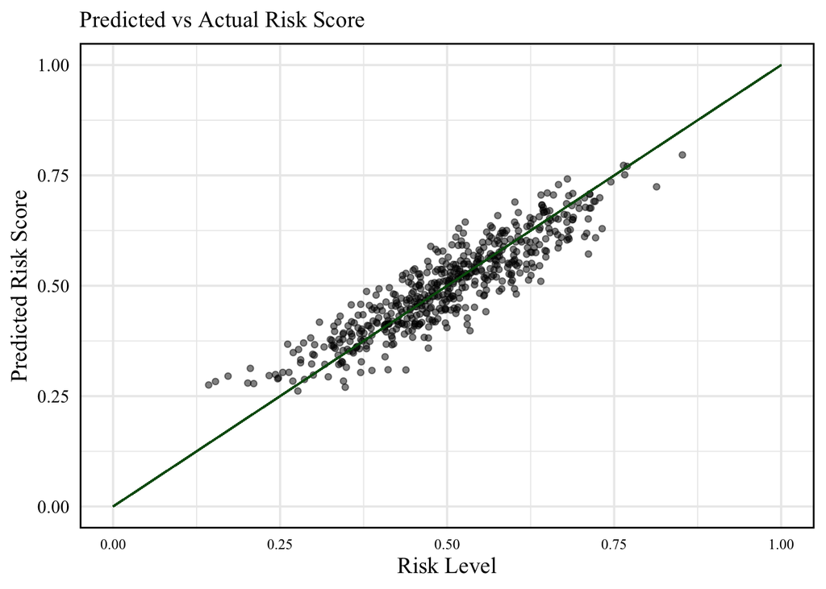

```r
df_remodel <- df_regression %>%
  mutate(risk_score_pred = predict(model, df_regression %>% as.data.frame()))

ggplot(df_remodel, aes(Overall_Risk_Score, risk_score_pred)) +
  geom_point(alpha = 0.5) +
  geom_segment(aes(x=0,y=0,xend=1,yend=1), colour = "#02590F") + labs(x="Risk Level") +
  labs(y="Predicted Risk Score") +
  ggtitle("Predicted vs Actual Risk Score") +
  theme_minimal(base_size = 14, base_family = "Times New Roman") +
                                    theme(legend.position = "right",
                                          legend.text = element_text(color = "black", size=11),
                                          legend.title = element_text(color = "black", size=14),
                                          axis.title = element_text(color = "black"),
                                          axis.text.x = element_text(color = "black",size= 9 ),
                                          axis.text.y = element_text(color = "black"),
                                          plot.title = element_text(color = "black", size = 14),
                                          panel.border = element_rect(color = "black", fill = NA, linewidth = 1 ))
```

Q: From the plot, we see that is is pretty well at getting thw risk scores using the training data.  
1. From here I wish to do a classification tree to predict risk levels

## Clasificaiton Tree for predicting risk level

```r
# function to split data

df_classification <- df %>% select(where(is.numeric), Risk_Level)

train <- runif(nrow(df_classification)) < 0.75
test <- !train

classification_tree <- rpart(Risk_Level~Age + Smoking + Alcohol_Use + Obesity + Family_History + Diet_Red_Meat + Diet_Salted_Processed + Fruit_Veg_Intake + Physical_Activity + Air_Pollution + Occupational_Hazards + BRCA_Mutation + H_Pylori_Infection + Calcium_Intake + Physical_Activity_Level,
                             data = df_classification %>% filter(train),
                             method = "class")

summary(classification_tree)
```

```
## Call:
## rpart(formula = Risk_Level ~ Age + Smoking + Alcohol_Use + Obesity +
##     Family_History + Diet_Red_Meat + Diet_Salted_Processed +
##     Fruit_Veg_Intake + Physical_Activity + Air_Pollution + Occupational_Hazards +
##     BRCA_Mutation + H_Pylori_Infection + Calcium_Intake + Physical_Activity_Level,
##     data = df_classification %>% filter(train), method = "class")
##   n= 1480
##
##           CP nsplit rel error    xerror       xstd
## 1 0.04075235      0 1.0000000 1.0000000 0.04958952
## 2 0.02351097      3 0.8777429 0.9968652 0.04953305
## 3 0.01567398      6 0.8056426 0.9404389 0.04848195
## 4 0.01000000      9 0.7586207 0.9310345 0.04830021
##
## Variable importance
##   Diet_Salted_Processed                 Smoking             Alcohol_Use
##                      23                      20                      20
##           Air_Pollution    Occupational_Hazards        Fruit_Veg_Intake
##                      10                       9                       5
##                 Obesity           Diet_Red_Meat                     Age
##                       4                       3                       3
## Physical_Activity_Level          Calcium_Intake
##                       2                       1
##
## Node number 1: 1480 observations,    complexity param=0.04075235
##   predicted class=Medium  expected loss=0.2155405  P(node) =1
##     class counts:    73   246  1161
##    probabilities: 0.049 0.166 0.784
##   left son=2 (658 obs) right son=3 (822 obs)
##   Primary splits:
##       Smoking               < 4.5  to the left,  improve=29.76940, (0 missing)
##       Alcohol_Use           < 2.5  to the left,  improve=27.86558, (0 missing)
##       Air_Pollution         < 4.5  to the left,  improve=27.82696, (0 missing)
##       Diet_Salted_Processed < 3.5  to the left,  improve=13.39715, (0 missing)
##       Occupational_Hazards  < 5.5  to the left,  improve=10.52937, (0 missing)
##   Surrogate splits:
##       Air_Pollution < 3.5  to the left,  agree=0.703, adj=0.331, (0 split)
##       Alcohol_Use   < 1.5  to the left,  agree=0.577, adj=0.049, (0 split)
##       Age           < 44.5 to the left,  agree=0.571, adj=0.035, (0 split)
##       Obesity       < 9.5  to the right, agree=0.570, adj=0.032, (0 split)
```

[output cut: 159 more lines]

```
##
## Node number 41: 11 observations
##   predicted class=Medium  expected loss=0.2727273  P(node) =0.007432432
##     class counts:     0     3     8
##    probabilities: 0.000 0.273 0.727
##
## Node number 42: 22 observations
##   predicted class=Low     expected loss=0.3181818  P(node) =0.01486486
##     class counts:     0    15     7
##    probabilities: 0.000 0.682 0.318
##
## Node number 43: 86 observations
##   predicted class=Medium  expected loss=0.2325581  P(node) =0.05810811
##     class counts:     0    20    66
##    probabilities: 0.000 0.233 0.767
```

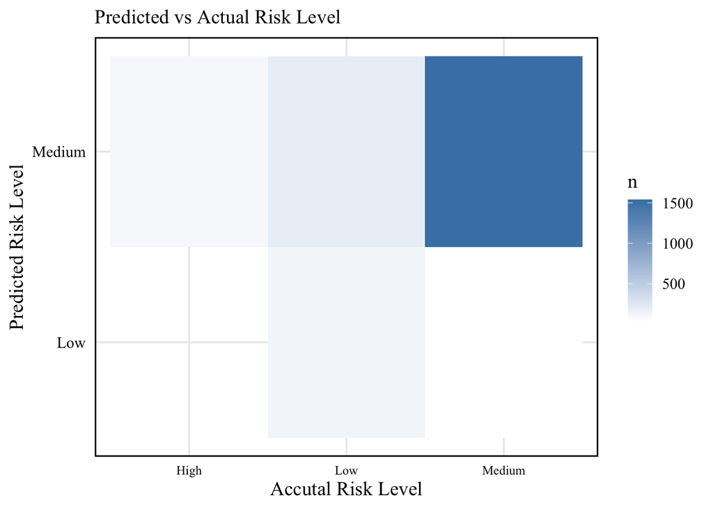

```r
df_classification$risk_lvl_prediction <- predict(classification_tree, newdata =  df_classification)

df_classification <- df_classification %>% mutate(predicted = colnames(risk_lvl_prediction)[max.col(risk_lvl_prediction)])

conf_mat <- df_classification %>% count(Risk_Level,predicted)

ggplot(conf_mat, aes(x = Risk_Level, y = predicted, fill=n)) +
  geom_tile() +
  scale_fill_gradient(low = "white", high = "steelblue") +
  labs(x="Accutal Risk Level") +
  labs(y="Predicted Risk Level") +
  ggtitle("Predicted vs Actual Risk Level") +
  theme_minimal(base_size = 14, base_family = "Times New Roman") +
                                    theme(legend.position = "right",
                                          legend.text = element_text(color = "black", size=11),
                                          legend.title = element_text(color = "black", size=14),
                                          axis.title = element_text(color = "black"),
                                          axis.text.x = element_text(color = "black",size= 9 ),
                                          axis.text.y = element_text(color = "black"),
                                          plot.title = element_text(color = "black", size = 14),
                                          panel.border = element_rect(color = "black", fill = NA, linewidth = 1 ))
```

Q: From the heat map, we see that the model was good at preidctig the medium levels of risk, however for te other levels of risk ,it was not as good.  
1. From here, I wanted to do a dimensionality reduction to identify if we can use less covarites to accuralty predict which covariates influence the chance of getting a type of cancer.

## Dimetionality reduction

```r
# conducting PCA

pca_cancer <- df %>% select(Smoking:Calcium_Intake) %>%
  mutate(across(c(Smoking:Calcium_Intake), ~as.numeric(.x)))

pca <- prcomp(pca_cancer)
summary(pca)
```

```
## Importance of components:
##                           PC1    PC2    PC3    PC4     PC5     PC6     PC7
## Standard deviation     4.1144 3.7389 3.2705 3.2188 3.08948 2.96983 2.86018
## Proportion of Variance 0.1711 0.1413 0.1081 0.1047 0.09646 0.08913 0.08267
## Cumulative Proportion  0.1711 0.3124 0.4204 0.5252 0.62162 0.71076 0.79343
##                            PC8     PC9    PC10    PC11    PC12    PC13
## Standard deviation     2.74010 2.66285 2.34579 0.39652 0.38726 0.17625
## Proportion of Variance 0.07588 0.07166 0.05561 0.00159 0.00152 0.00031
## Cumulative Proportion  0.86931 0.94097 0.99658 0.99817 0.99969 1.00000
```

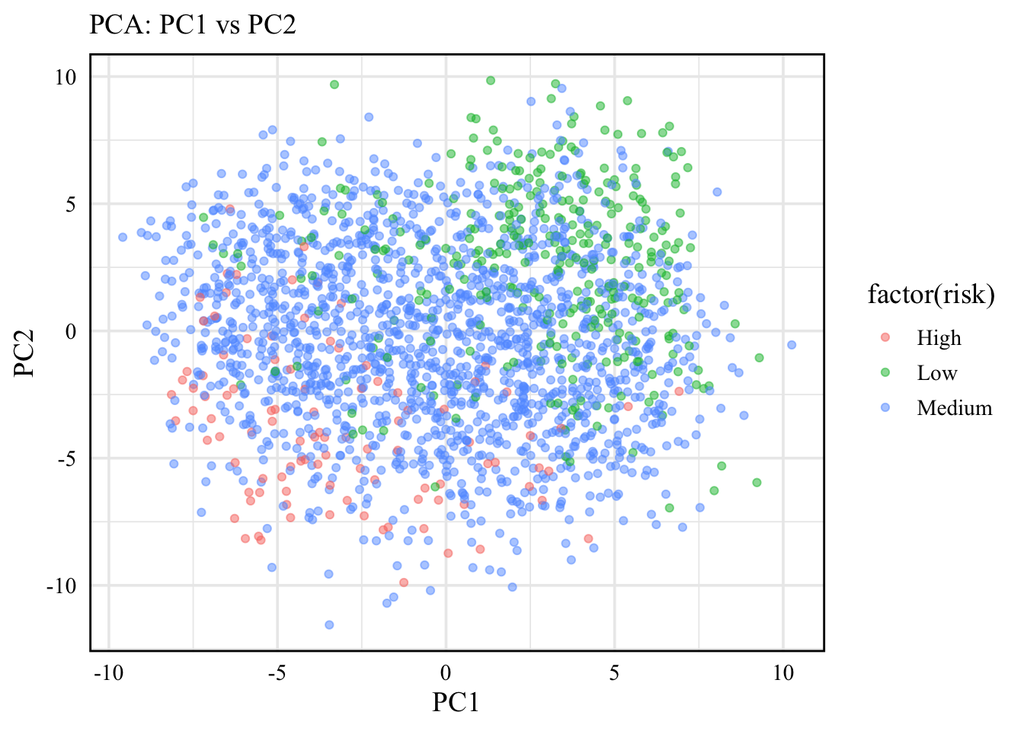

```r
all_pcs <- as.data.frame(pca$x)

all_pcs <- all_pcs %>% mutate(risk = df$Risk_Level)
pc1_pc2 <- all_pcs %>% select(PC1, PC2, risk)

# graphing the data
pc1_pc2 %>% ggplot(aes(x=PC1, y=PC2,  color = factor(risk))) +
  geom_point(alpha=0.5) +
  labs(x="PC1") +
  labs(y="PC2") +
  ggtitle("PCA: PC1 vs PC2") +
  theme_minimal(base_size = 14, base_family = "Times New Roman") +
                                    theme(legend.position = "right",
                                          legend.text = element_text(color = "black", size=11),
                                          legend.title = element_text(color = "black", size=14),
                                          axis.title = element_text(color = "black"),
                                          axis.text.x = element_text(color = "black", ),
                                          axis.text.y = element_text(color = "black"),
                                          plot.title = element_text(color = "black", size = 14),
                                          panel.border = element_rect(color = "black", fill = NA, linewidth = 1 ))
```